# Differentially expressed protein analysis of SWATH data using student’s test

This worflow shows how to process data from SWATH-MS protein quantification, in order to study differential expression of the proteins between the different conditions.

The data in this example come from : Bjelosevic S, Pascovici D, Ping H, et.al. Quantitative age-specific variability of plasma proteins in healthy neonates, children and adults. Molecular & Cellular Proteomics (March 23 2017). Four conditions are compared each conditions have ten replicates :  
-neonates  
-child less than one year old  
-child between 1 and five years old  
-adults

146 proteins were identified and quantified.

# 1. loading and visualizing the data

```r
data<-read.table("SWATH.example.data.csv", sep=",",header=T, row.names = 1)
data
```

|  | Sample.1 | Sample.2 | Sample.3 | Sample.4 | Sample.5 | Sample.6 | Sample.7 | Sample.8 | Sample.9 | Sample.10 | Sample.11 | Sample.12 | Sample.13 | Sample.14 | Sample.15 | Sample.16 | Sample.17 | Sample.18 | Sample.19 | Sample.20 | Sample.21 | Sample.22 | Sample.23 | Sample.24 | Sample.25 | Sample.26 | Sample.27 | Sample.28 | Sample.29 | … |
| --- | --- | --- | --- | --- | --- | --- | --- | --- | --- | --- | --- | --- | --- | --- | --- | --- | --- | --- | --- | --- | --- | --- | --- | --- | --- | --- | --- | --- | --- | --- |
| sp\|A0M8Q6\|LAC7_HUMAN | 1.115502e+05 | 9.203458e+03 | 6.672549e+04 | 5.991088e+04 | 1.642215e+05 | 9.143973e+03 | 6.409901e+06 | 1.238785e+04 | 7.809981e+03 | 4.553976e+04 | 5.593150e+04 | 3.501655e+04 | 3.254635e+04 | 5.664431e+04 | 1.839196e+04 | 3.113175e+06 | 1.320937e+04 | 1.982661e+04 | 4.225821e+06 | 1.682750e+05 | 2.277252e+06 | 6.397863e+06 | 3.189287e+06 | 3.628608e+06 | 4.121755e+06 | 1.426761e+05 | 4.140672e+06 | 1.802475e+05 | 5.826897e+06 | … |
| sp\|B9A064\|IGLL5_HUMAN | 6.555987e+06 | 7.765069e+06 | 9.187741e+06 | 7.691362e+06 | 1.498776e+07 | 1.374116e+07 | 8.230958e+06 | 8.681886e+06 | 9.058707e+06 | 8.188822e+06 | 2.531991e+06 | 3.934526e+06 | 1.700102e+06 | 4.418838e+06 | 5.584636e+06 | 3.334236e+06 | 3.871055e+06 | 3.312348e+06 | 4.053520e+06 | 4.567918e+06 | 9.331017e+06 | 1.055792e+07 | 6.857038e+06 | 8.977858e+06 | 9.036241e+06 | 1.460044e+07 | 1.090076e+07 | 1.178051e+07 | 9.930735e+06 | … |
| sp\|O14791\|APOL1_HUMAN | 1.001121e+07 | 6.967989e+06 | 8.196725e+06 | 7.793772e+06 | 4.469132e+06 | 2.344268e+05 | 1.072176e+07 | 2.178108e+05 | 1.626200e+05 | 2.884709e+05 | 8.933724e+06 | 8.123464e+05 | 8.198270e+05 | 4.858403e+05 | 6.382900e+05 | 5.737175e+06 | 7.894232e+06 | 7.794366e+06 | 3.373264e+05 | 8.217965e+05 | 1.036517e+06 | 8.268936e+05 | 8.869152e+05 | 1.007503e+06 | 9.127178e+05 | 1.089386e+06 | 7.271341e+05 | 1.024629e+06 | 5.359292e+05 | … |
| sp\|O43866\|CD5L_HUMAN | 8.159506e+04 | 6.204646e+05 | 1.567635e+05 | 2.038546e+05 | 1.109301e+05 | 2.877470e+05 | 6.997967e+04 | 2.019811e+05 | 1.118168e+05 | 1.388014e+05 | 1.591100e+06 | 8.304909e+05 | 1.683988e+06 | 8.369937e+05 | 1.024494e+06 | 1.487672e+06 | 8.896914e+05 | 6.911559e+05 | 7.834091e+05 | 1.137166e+06 | 1.474772e+06 | 3.229527e+06 | 5.422559e+05 | 7.143334e+05 | 1.521902e+06 | 9.076956e+05 | 9.373061e+05 | 1.809989e+06 | 1.370390e+06 | … |
| sp\|O75636\|FCN3_HUMAN | 2.559217e+05 | 3.979038e+05 | 3.513910e+05 | 3.117654e+05 | 3.523802e+05 | 4.164043e+05 | 1.661627e+05 | 1.592014e+05 | 3.600346e+05 | 4.019163e+05 | 6.269995e+05 | 4.309955e+05 | 5.264501e+05 | 3.827408e+05 | 4.612140e+05 | 4.070175e+05 | 4.470716e+05 | 4.385885e+05 | 2.046635e+05 | 3.899665e+05 | 3.983688e+05 | 4.408848e+05 | 3.895040e+05 | 4.880614e+05 | 3.715512e+05 | 2.801026e+05 | 4.840683e+05 | 4.352776e+05 | 3.844813e+05 | … |
| sp\|O75882\|ATRN_HUMAN | 1.767532e+05 | 1.558307e+05 | 1.316840e+05 | 1.857808e+05 | 2.112565e+05 | 2.224510e+05 | 1.410986e+05 | 1.870620e+05 | 1.454212e+05 | 1.771302e+05 | 2.103269e+05 | 1.597351e+05 | 1.954820e+05 | 1.480458e+05 | 2.178803e+05 | 2.424497e+05 | 1.444728e+05 | 2.148264e+05 | 1.355214e+05 | 1.719731e+05 | 2.185981e+05 | 2.668701e+05 | 2.079915e+05 | 4.137703e+05 | 2.058052e+05 | 1.970503e+05 | 1.905642e+05 | 2.319276e+05 | 2.143148e+05 | … |
| sp\|O95445\|APOM_HUMAN | 1.020017e+06 | 2.250939e+06 | 1.349443e+06 | 9.617744e+05 | 1.058482e+06 | 1.818463e+06 | 1.528318e+06 | 1.818339e+06 | 2.021296e+06 | 2.281483e+06 | 2.892953e+06 | 1.650583e+06 | 3.291866e+06 | 2.130070e+06 | 3.015864e+06 | 2.538538e+06 | 1.714518e+06 | 2.612111e+06 | 1.372180e+06 | 1.699907e+06 | 1.902994e+06 | 2.084267e+06 | 2.146561e+06 | 1.596102e+06 | 2.170206e+06 | 2.027062e+06 | 1.920462e+06 | 1.258234e+06 | 2.237601e+06 | … |
| sp\|P00450\|CERU_HUMAN | 1.182729e+07 | 1.821801e+07 | 2.511296e+07 | 3.728021e+07 | 1.543016e+07 | 1.985402e+07 | 2.195637e+07 | 2.699302e+07 | 2.181524e+07 | 1.232113e+07 | 3.956893e+07 | 4.466537e+07 | 3.973772e+07 | 3.389234e+07 | 3.734018e+07 | 3.890265e+07 | 3.234811e+07 | 3.486318e+07 | 3.086611e+07 | 5.164749e+07 | 4.644504e+07 | 4.955205e+07 | 5.197502e+07 | 5.020298e+07 | 4.124388e+07 | 3.203656e+07 | 5.005262e+07 | 5.292072e+07 | 4.146162e+07 | … |
| sp\|P00734\|THRB_HUMAN | 5.268991e+06 | 1.080345e+07 | 1.063795e+07 | 8.633835e+06 | 5.519106e+06 | 1.054838e+07 | 5.367526e+06 | 1.129812e+07 | 1.155138e+07 | 1.037768e+07 | 1.819373e+07 | 1.086306e+07 | 1.516987e+07 | 1.108148e+07 | 1.580313e+07 | 1.372989e+07 | 9.926704e+06 | 1.290357e+07 | 1.302017e+07 | 1.380308e+07 | 1.234260e+07 | 1.385705e+07 | 1.472569e+07 | 1.725223e+07 | 1.378623e+07 | 1.082918e+07 | 1.498588e+07 | 1.708767e+07 | 1.292654e+07 | … |
| sp\|P00736\|C1R_HUMAN | 7.147036e+05 | 6.590983e+05 | 7.095505e+05 | 9.111163e+05 | 7.567476e+05 | 1.142857e+06 | 7.139793e+05 | 9.441301e+05 | 9.327809e+05 | 6.085300e+05 | 4.710490e+05 | 6.094145e+05 | 6.985228e+05 | 5.892876e+05 | 8.123817e+05 | 7.464940e+05 | 8.176705e+05 | 7.110055e+05 | 7.786733e+05 | 7.298765e+05 | 8.178142e+05 | 6.087981e+05 | 8.432841e+05 | 8.864449e+05 | 9.095868e+05 | 7.560945e+05 | 6.876085e+05 | 9.026293e+05 | 5.807046e+05 | … |

[output cut: 136 more lines]

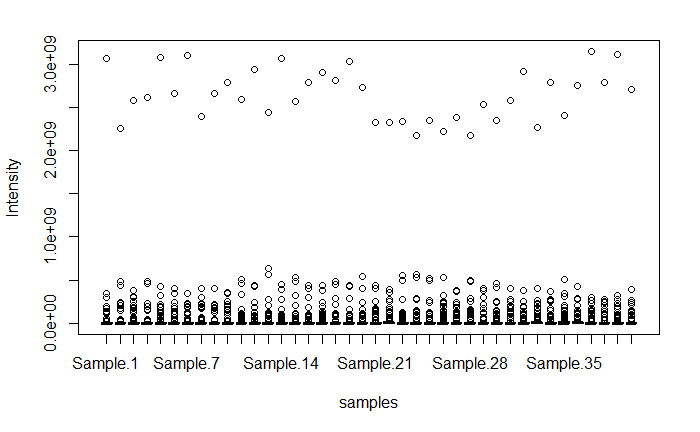

```r
boxplot(data, ylab="Intensity", xlab="samples")
```

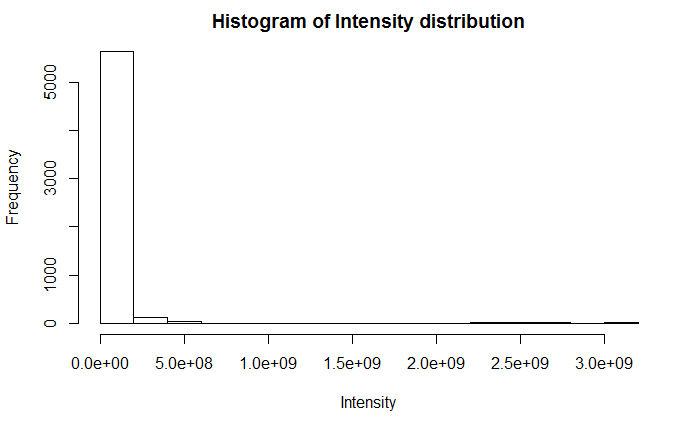

```r
hist(as.numeric(unlist(data)), main = "Histogram of Intensity distribution",  xlab = "Intensity")
```

# 2. log transform

The data is log transformed so that:  
-the spread is even across the intensity range  
-the variability stays constant at all intensity levels  
-the distribution of experimental errors is normal (necessary to apply most of the statistical test)  
-the distribution of intensity is bell shaped

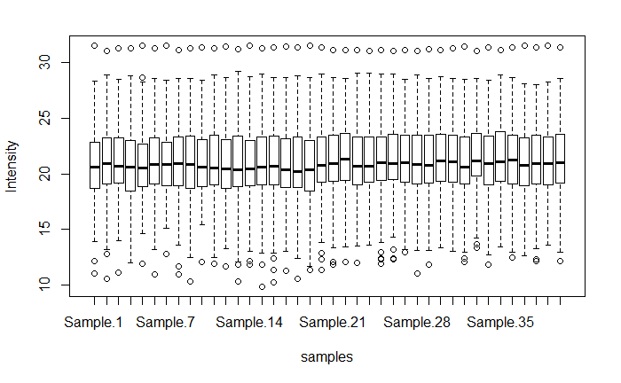

```r
data <- log2(data)
boxplot(data, ylab="Intensity", xlab="samples")
```

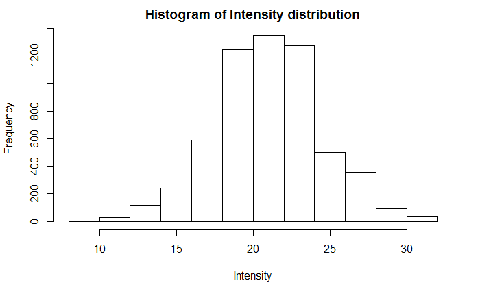

```r
hist(as.numeric(unlist(data)), main = "Histogram of Intensity distribution",  xlab = "Intensity")
```

# 3. Normalization

Normalization allows to resolve the bias and errors introduced between the samples by the experimental tools or the samples preparation. Normalization relies on the fact that most of the proteins are expected to be expressed the same way between the samples, so it is necessary to remove the differences induced by the experiment to not overestimate the differencial expression. here we use the mean center and scaling normalization : centering assure that the mean of the different samples is equal (set to 0), and scaling sets the standard deviation to 1.

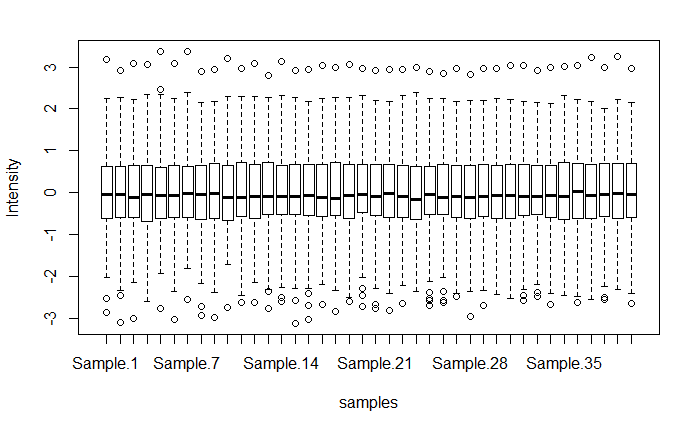

```r
norm.data <- scale(data) ##mean center and scaling normalization
boxplot(norm.data, ylab="Intensity", xlab="samples")
```

# 4. Differential expression annalysis

## 4.1 experimental design

In order to perform the pairwise comparison we need to define the experimental design :  
- the design matrix generated with model.matrix(), which identify which sample belong to which condition.

```r
#for this specific data :
exp.design <- data.frame(samples = colnames(data), condition = 1)
exp.design$condition[1:10] = "control"
exp.design$condition[11:20] = "lessone"
exp.design$condition[21:30] = "onetofive"
exp.design$condition[31:40] = "adult"
design <- model.matrix(~0 + exp.design$condition, data = exp.design)
colnames(design) <- sort(unique(exp.design$condition))
row.names(design) <- exp.design$samples
as.data.frame(design)
```

|  | adult | control | lessone | onetofive |
| --- | --- | --- | --- | --- |
| Sample.1 | 0 | 1 | 0 | 0 |
| Sample.2 | 0 | 1 | 0 | 0 |
| Sample.3 | 0 | 1 | 0 | 0 |
| Sample.4 | 0 | 1 | 0 | 0 |
| Sample.5 | 0 | 1 | 0 | 0 |
| Sample.6 | 0 | 1 | 0 | 0 |
| Sample.7 | 0 | 1 | 0 | 0 |
| Sample.8 | 0 | 1 | 0 | 0 |
| Sample.9 | 0 | 1 | 0 | 0 |
| Sample.10 | 0 | 1 | 0 | 0 |

[output cut: 30 more lines]

- the contrast matrix generated with makeContrasts(), which define the comparison to perform between the differents conditions.

```r
library(limma)
contrast <- makeContrasts(adult-control, lessone-control, onetofive-control, adult+lessone+onetofive-control, levels=design)
as.data.frame(contrast)
```

|  | adult - control | lessone - control | onetofive - control | adult + lessone + onetofive - control |
| --- | --- | --- | --- | --- |
| adult | 1 | 0 | 0 | 1 |
| control | -1 | -1 | -1 | -1 |
| lessone | 0 | 1 | 0 | 1 |
| onetofive | 0 | 0 | 1 | 1 |

## 4.2 Fold change and statistical test calcul

For each comparison and for each protein the fold change and the student p value are calculated. the results are stocked in a list of data frame (each data frame is the result for one comparison defined in the contrast matrix). The fold change is the mean intensity difference between two condition, a fold change of zero means no difference a negative one a down-regulation and a positive one an up-regulation.

```r
  ## in this example there are four pairwise comparison to perform:
  nbComp<-ncol(contrast)
  Results<-list() ## a list of data frames containing the results

  for (i in 1:nbComp){ ## for each comparison defined in the contrast matrix :

    c1<-row.names(contrast)[contrast[,i] == 1 ] ## names of the first conditions of the pairwise comparison
    c2<-row.names(contrast)[contrast[,i] == -1 ] ## names of the second conditions of the pairwise comparison

    samplesc1 <- row.names(design)[row(as.matrix(design[,c1]))[design[,c1]==1]] ## names of the samples belonging to the first conditions of the pairwise comparison
    samplesc2 <- row.names(design)[row(as.matrix(design[,c2]))[design[,c2]==1]] ## names of the samples belonging to the second conditions of the pairwise comparison

    colc1 <- which(colnames(norm.data) %in% samplesc1) ## columns number in the dataset of the samples for the first comparison of the pairwise comparison
    colc2 <- which(colnames(norm.data) %in% samplesc2) ## columns number in the dataset of the samples for the second comparison of the pairwise comparison

    p.value<-apply(norm.data,1,function(x){t.test(as.numeric(x[colc2]),as.numeric(x[colc1]), alternative = "t") $p.value}) ## calcul of the p.value of the student test between the conditions of the pairwise comparison
    adjust.p.value<-p.adjust(p.value, method = "BH") ## corrrection of the p.value with the Benjamini & Hochberg technique

    fc<-rowMeans(norm.data[,colc1])-rowMeans(norm.data[,colc2]) ## fold change calcul between the conditions of the pairwise comparison

    ## stocking the data frame containing the results in a list :
    Results[[i]]<-data.frame(protein=c(row.names(norm.data)))
    Results[[i]][paste("p.value.",colnames(contrast)[i],sep="")]=c(p.value)
    Results[[i]][paste("adjust.p.value.",colnames(contrast)[i],sep="")]=c(adjust.p.value)
    Results[[i]][paste("fc.",colnames(contrast)[i],sep="")]=c(fc)
    print(Results[[i]])
  }
```

| protein | p.value.adult - control | adjust.p.value.adult - control | fc.adult - control |
| --- | --- | --- | --- |
| sp\|A0M8Q6\|LAC7_HUMAN | 2.406951e-04 | 9.010637e-04 | 1.631180789 |
| sp\|B9A064\|IGLL5_HUMAN | 7.753311e-01 | 8.385062e-01 | 0.015949434 |
| sp\|O14791\|APOL1_HUMAN | 8.106065e-01 | 8.575982e-01 | 0.073466987 |
| sp\|O43866\|CD5L_HUMAN | 4.601912e-07 | 4.799137e-06 | 0.837934288 |
| sp\|O75636\|FCN3_HUMAN | 3.549491e-02 | 7.003050e-02 | -0.139000317 |
| sp\|O75882\|ATRN_HUMAN | 4.992717e-02 | 9.063108e-02 | -0.087579437 |
| sp\|O95445\|APOM_HUMAN | 4.891117e-02 | 9.039279e-02 | -0.092762749 |
| sp\|P00450\|CERU_HUMAN | 4.119260e-02 | 7.957051e-02 | 0.142998456 |
| sp\|P00734\|THRB_HUMAN | 1.053849e-01 | 1.672413e-01 | 0.058349006 |
| sp\|P00736\|C1R_HUMAN | 7.901590e-04 | 2.354351e-03 | -0.169672002 |

[output cut: 136 more lines]

| protein | p.value.lessone - control | adjust.p.value.lessone - control | fc.lessone - control |
| --- | --- | --- | --- |
| sp\|A0M8Q6\|LAC7_HUMAN | 4.224023e-01 | 4.855963e-01 | 0.317002510 |
| sp\|B9A064\|IGLL5_HUMAN | 5.972440e-06 | 2.235837e-05 | -0.385251511 |
| sp\|O14791\|APOL1_HUMAN | 9.570983e-01 | 9.570983e-01 | -0.016757279 |
| sp\|O43866\|CD5L_HUMAN | 5.848262e-07 | 3.557692e-06 | 0.859476700 |
| sp\|O75636\|FCN3_HUMAN | 2.853630e-03 | 5.341410e-03 | 0.209540669 |
| sp\|O75882\|ATRN_HUMAN | 1.017487e-02 | 1.688104e-02 | 0.111882782 |
| sp\|O95445\|APOM_HUMAN | 1.723147e-03 | 3.593992e-03 | 0.185597497 |
| sp\|P00450\|CERU_HUMAN | 3.156815e-04 | 7.946465e-04 | 0.244250480 |
| sp\|P00734\|THRB_HUMAN | 2.083584e-04 | 5.336898e-04 | 0.177329758 |
| sp\|P00736\|C1R_HUMAN | 9.215544e-01 | 9.279100e-01 | -0.004209150 |

[output cut: 136 more lines]

| protein | p.value.onetofive - control | adjust.p.value.onetofive - control | fc.onetofive - control |
| --- | --- | --- | --- |
| sp\|A0M8Q6\|LAC7_HUMAN | 4.652123e-04 | 1.234927e-03 | 1.4766374847 |
| sp\|B9A064\|IGLL5_HUMAN | 1.936168e-01 | 2.523933e-01 | -0.0659396184 |
| sp\|O14791\|APOL1_HUMAN | 1.287337e-01 | 1.824769e-01 | -0.4316209199 |
| sp\|O43866\|CD5L_HUMAN | 8.243127e-07 | 7.079392e-06 | 0.7967277553 |
| sp\|O75636\|FCN3_HUMAN | 3.619808e-01 | 4.313622e-01 | 0.0504725518 |
| sp\|O75882\|ATRN_HUMAN | 2.544584e-01 | 3.202666e-01 | 0.0474305286 |
| sp\|O95445\|APOM_HUMAN | 9.831153e-01 | 9.831153e-01 | 0.0009937847 |
| sp\|P00450\|CERU_HUMAN | 1.684753e-04 | 5.019875e-04 | 0.2620723346 |
| sp\|P00734\|THRB_HUMAN | 4.942169e-03 | 1.002162e-02 | 0.1244329891 |
| sp\|P00736\|C1R_HUMAN | 2.057543e-02 | 3.413650e-02 | -0.1068956224 |

[output cut: 136 more lines]

| protein | p.value.adult + lessone + onetofive - control | adjust.p.value.adult + lessone + onetofive - control | fc.adult + lessone + onetofive - control |
| --- | --- | --- | --- |
| sp\|A0M8Q6\|LAC7_HUMAN | 2.907706e-03 | 6.064644e-03 | 1.141606928 |
| sp\|B9A064\|IGLL5_HUMAN | 1.658791e-02 | 2.917873e-02 | -0.145080565 |
| sp\|O14791\|APOL1_HUMAN | 6.531657e-01 | 7.170090e-01 | -0.124970404 |
| sp\|O43866\|CD5L_HUMAN | 1.196586e-06 | 8.319120e-06 | 0.831379581 |
| sp\|O75636\|FCN3_HUMAN | 4.992897e-01 | 5.652715e-01 | 0.040337635 |
| sp\|O75882\|ATRN_HUMAN | 5.233374e-01 | 5.877482e-01 | 0.023911291 |
| sp\|O95445\|APOM_HUMAN | 4.994523e-01 | 5.652715e-01 | 0.031276178 |
| sp\|P00450\|CERU_HUMAN | 7.899645e-04 | 2.023418e-03 | 0.216440424 |
| sp\|P00734\|THRB_HUMAN | 3.923565e-03 | 7.741088e-03 | 0.120037251 |
| sp\|P00736\|C1R_HUMAN | 1.986380e-02 | 3.295585e-02 | -0.093592258 |

[output cut: 136 more lines]

## 4.3 Differentially expressed proteins

```r
thresh_fc <- 0.5
thresh_p <- 0.05
deProt <- Results
for(i in 1:length(Results)){
    fc = as.data.frame(deProt[[i]])[,4]
    p = as.data.frame(deProt[[i]])[,3]
    dt <-as.data.frame(deProt[[i]])
    deProt[[i]] <- dt[which(p<=thresh_p & abs(fc)>=thresh_fc),]
    print(as.data.frame(deProt[[i]]))
  }
```

|  | protein | p.value.adult - control | adjust.p.value.adult - control | fc.adult - control |
| --- | --- | --- | --- | --- |
| 1 | sp\|A0M8Q6\|LAC7_HUMAN | 2.406951e-04 | 9.010637e-04 | 1.6311808 |
| 4 | sp\|O43866\|CD5L_HUMAN | 4.601912e-07 | 4.799137e-06 | 0.8379343 |
| 11 | sp\|P00738\|HPT_HUMAN | 3.880216e-03 | 9.938800e-03 | 0.6941363 |
| 24 | sp\|P01591\|IGJ_HUMAN | 7.710566e-13 | 3.752475e-11 | 1.0415256 |
| 42 | sp\|P01871\|IGHM_HUMAN | 1.153722e-10 | 2.105543e-09 | 0.8883829 |
| 43 | sp\|P01876\|IGHA1_HUMAN | 4.872890e-19 | 7.114419e-17 | 1.6861620 |
| 44 | sp\|P01877\|IGHA2_HUMAN | 1.146306e-09 | 1.859563e-08 | 1.3696999 |
| 46 | sp\|P02452\|CO1A1_HUMAN | 1.157761e-11 | 4.225827e-10 | -0.9871317 |
| 69 | sp\|P02771\|FETA_HUMAN | 4.921469e-06 | 3.421593e-05 | -0.8977556 |
| 82 | sp\|P04220\|MUCB_HUMAN | 1.508962e-11 | 4.406169e-10 | 0.9910358 |

[output cut: 7 more lines]

|  | protein | p.value.lessone - control | adjust.p.value.lessone - control | fc.lessone - control |
| --- | --- | --- | --- | --- |
| 4 | sp\|O43866\|CD5L_HUMAN | 5.848262e-07 | 3.557692e-06 | 0.8594767 |
| 11 | sp\|P00738\|HPT_HUMAN | 9.788475e-04 | 2.198642e-03 | 0.7869264 |
| 24 | sp\|P01591\|IGJ_HUMAN | 2.440667e-11 | 1.065409e-09 | 0.8128108 |
| 34 | sp\|P01772\|HV311_HUMAN | 9.903522e-08 | 7.400488e-07 | -0.6933558 |
| 35 | sp\|P01780\|HV319_HUMAN | 1.393043e-05 | 4.729868e-05 | -0.6813459 |
| 37 | sp\|P01834\|IGKC_HUMAN | 3.747021e-09 | 5.470651e-08 | -0.5202104 |
| 41 | sp\|P01861\|IGHG4_HUMAN | 1.196634e-04 | 3.176519e-04 | -0.6832160 |
| 42 | sp\|P01871\|IGHM_HUMAN | 7.450609e-11 | 2.175578e-09 | 0.8033905 |
| 43 | sp\|P01876\|IGHA1_HUMAN | 6.379205e-10 | 1.034849e-08 | 0.9287175 |
| 69 | sp\|P02771\|FETA_HUMAN | 1.317463e-05 | 4.579753e-05 | -0.7670350 |

[output cut: 12 more lines]

|  | protein | p.value.onetofive - control | adjust.p.value.onetofive - control | fc.onetofive - control |
| --- | --- | --- | --- | --- |
| 1 | sp\|A0M8Q6\|LAC7_HUMAN | 4.652123e-04 | 1.234927e-03 | 1.4766375 |
| 4 | sp\|O43866\|CD5L_HUMAN | 8.243127e-07 | 7.079392e-06 | 0.7967278 |
| 11 | sp\|P00738\|HPT_HUMAN | 3.203462e-04 | 8.951642e-04 | 0.9246058 |
| 24 | sp\|P01591\|IGJ_HUMAN | 5.088075e-08 | 9.285737e-07 | 0.8262717 |
| 42 | sp\|P01871\|IGHM_HUMAN | 2.007807e-07 | 2.664908e-06 | 0.8021595 |
| 43 | sp\|P01876\|IGHA1_HUMAN | 4.499562e-09 | 1.313872e-07 | 1.2014716 |
| 44 | sp\|P01877\|IGHA2_HUMAN | 1.192740e-06 | 9.165267e-06 | 0.7083655 |
| 69 | sp\|P02771\|FETA_HUMAN | 1.131525e-06 | 9.165267e-06 | -0.9728462 |
| 75 | sp\|P04003\|C4BPA_HUMAN | 1.670372e-05 | 8.709798e-05 | 0.5500517 |
| 78 | sp\|P04196\|HRG_HUMAN | 4.624479e-06 | 3.068973e-05 | 0.6042300 |

[output cut: 6 more lines]

|  | protein | p.value.adult + lessone + onetofive - control | adjust.p.value.adult + lessone + onetofive - control | fc.adult + lessone + onetofive - control |
| --- | --- | --- | --- | --- |
| 1 | sp\|A0M8Q6\|LAC7_HUMAN | 2.907706e-03 | 6.064644e-03 | 1.1416069 |
| 4 | sp\|O43866\|CD5L_HUMAN | 1.196586e-06 | 8.319120e-06 | 0.8313796 |
| 11 | sp\|P00738\|HPT_HUMAN | 8.601830e-04 | 2.093112e-03 | 0.8018895 |
| 24 | sp\|P01591\|IGJ_HUMAN | 1.274246e-16 | 9.301994e-15 | 0.8935360 |
| 42 | sp\|P01871\|IGHM_HUMAN | 1.091929e-12 | 2.657027e-11 | 0.8313110 |
| 43 | sp\|P01876\|IGHA1_HUMAN | 1.344077e-19 | 1.962352e-17 | 1.2721171 |
| 44 | sp\|P01877\|IGHA2_HUMAN | 2.425418e-11 | 4.426388e-10 | 0.8407909 |
| 69 | sp\|P02771\|FETA_HUMAN | 6.232832e-06 | 3.499975e-05 | -0.8792122 |
| 78 | sp\|P04196\|HRG_HUMAN | 1.529073e-05 | 6.764989e-05 | 0.5346688 |
| 82 | sp\|P04220\|MUCB_HUMAN | 2.125308e-13 | 6.205900e-12 | 0.9091284 |

[output cut: 5 more lines]

## 4.4 Volcano Plot

For each pairwise comparison in the results list a volcano plot is created, volcano plots are the best way to visualise the p value and the fold change at the same time.

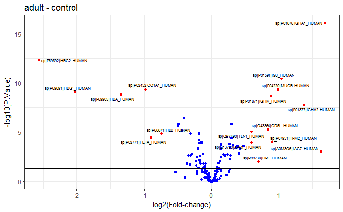

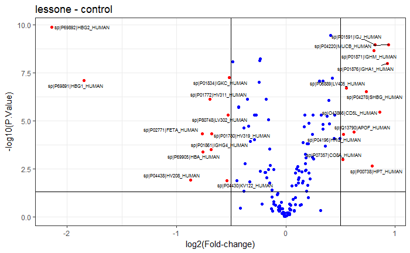

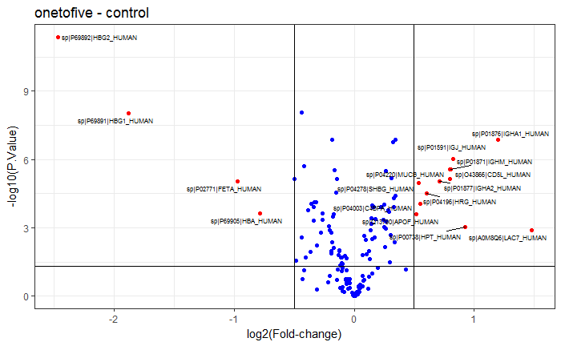

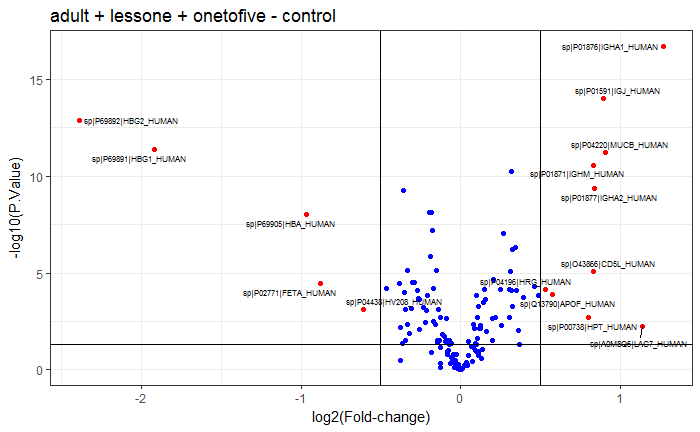

```r
library(ggplot2)
library(ggrepel)
tresh_fc = 0.5 ## Fold change threshold
tresh_p = 0.05 ## p.value treshold
for(i in 1:length(Results)){
  plotTitle <- substr(colnames(Results[[i]])[2], 9 ,nchar(colnames(Results[[i]])[2]))
  values <- as.data.frame(Results[[i]])
  forplot <- data.frame(x=as.numeric(values[,4]), y=-log10(values[,3]), id=as.character(values[,1]))
  tmp <- forplot[as.numeric(forplot$y)>=-log10(tresh_fc) & abs(forplot$x)>tresh_fc,]
  p <- ggplot(forplot) + geom_point(aes(x, y , color = ifelse(y>=-log10(tresh_p) & abs(x)>=tresh_fc, "not signi", "FC")),show.legend = F) +
    scale_color_manual(values = c("blue", "red")) +
    geom_text_repel(data = subset(forplot, abs(forplot$x)>=tresh_fc & forplot$y>=-log10(tresh_p)),
                    aes(x,y,label = id),
                    size = 2) +
    geom_vline(xintercept = tresh_fc ) +
    geom_vline(xintercept = -tresh_fc) +
    geom_hline(yintercept = -log10(tresh_p)) +
    labs(title = plotTitle,x="log2(Fold-change)", y="-log10(P.Value)") + theme_bw()
    print(p)
}
```

```r
res <- vector()
for(i in 1:length(deProt)){
  res <- append(res, as.character(deProt[[i]][,1]))
}
res <- unique(res)
print(res)
```

```
 [1] "sp|A0M8Q6|LAC7_HUMAN"  "sp|O43866|CD5L_HUMAN"  "sp|P00738|HPT_HUMAN"   "sp|P01591|IGJ_HUMAN"
 [5] "sp|P01871|IGHM_HUMAN"  "sp|P01876|IGHA1_HUMAN" "sp|P01877|IGHA2_HUMAN" "sp|P02452|CO1A1_HUMAN"
 [9] "sp|P02771|FETA_HUMAN"  "sp|P04220|MUCB_HUMAN"  "sp|P07951|TPM2_HUMAN"  "sp|P68871|HBB_HUMAN"
[13] "sp|P69891|HBG1_HUMAN"  "sp|P69892|HBG2_HUMAN"  "sp|P69905|HBA_HUMAN"   "sp|Q13790|APOF_HUMAN"
[17] "sp|Q9Y490|TLN1_HUMAN"  "sp|P01772|HV311_HUMAN" "sp|P01780|HV319_HUMAN" "sp|P01834|IGKC_HUMAN"
[21] "sp|P01861|IGHG4_HUMAN" "sp|P04196|HRG_HUMAN"   "sp|P04278|SHBG_HUMAN"  "sp|P04430|KV122_HUMAN"
[25] "sp|P04438|HV208_HUMAN" "sp|P06889|LV405_HUMAN" "sp|P07357|CO8A_HUMAN"  "sp|P80748|LV302_HUMAN"
[29] "sp|P04003|C4BPA_HUMAN"
```

```r
saveRDS(res, "resSCL.rds")
```

[output not shown]

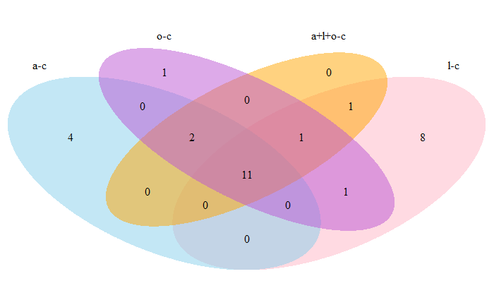

```r
library(VennDiagram)
grid.newpage()
draw.quad.venn(area1 = length(deProt[[1]][,1]),
               area2 = length(deProt[[2]][,1]),
               area3 = length(deProt[[3]][,1]),
               area4 = length(deProt[[4]][,1]),
               n12 = length(intersect(deProt[[1]][,1],deProt[[2]][,1])),
               n13 = length(intersect(deProt[[1]][,1],deProt[[3]][,1])),
               n14 = length(intersect(deProt[[1]][,1],deProt[[4]][,1])),
               n23 = length(intersect(deProt[[2]][,1],deProt[[3]][,1])),
               n24 = length(intersect(deProt[[2]][,1],deProt[[4]][,1])),
               n34 = length(intersect(deProt[[3]][,1],deProt[[4]][,1])),
               n123 = length(Reduce(intersect, list(deProt[[1]][,1],deProt[[2]][,1],deProt[[3]][,1]))),
               n124 = length(Reduce(intersect, list(deProt[[1]][,1],deProt[[2]][,1],deProt[[4]][,1]))),
               n134 = length(Reduce(intersect, list(deProt[[1]][,1],deProt[[3]][,1],deProt[[4]][,1]))),
               n234 = length(Reduce(intersect, list(deProt[[2]][,1],deProt[[3]][,1],deProt[[4]][,1]))),
               n1234 = length(Reduce(intersect,list(deProt[[1]][,1],deProt[[2]][,1],deProt[[3]][,1],deProt[[4]][,1]))),
               category = c("a-c","l-c","o-c","a+l+o-c"),
               lty = "blank", fill = c("skyblue", "pink1", "mediumorchid", "orange"))
```